# ggplot2 paketi

# 2 Pasta (Pie) Grafiği

Kategorik verilerin görselleştirilmesinde en popüler grafik türü şüphesiz pasta (pie) grafiğidir.

Pasta grafiğini `ggplot()` fonksiyonuyla elde etmek için öncelikle çubuk grafiği `geom_bar()` ile oluşturulur ve daha sonra `coord_polar()` fonksiyonuyla bu grafik pastaya dönüştürülür. Bu yapı aslında `ggplot2` paketinin kullanımını çok güzel özetlemektedir.

```r
library(ggplot2)
ggplot(melanoma,aes(x="",fill=factor(status)))+
  geom_bar()+
  coord_polar(theta = "y",start = 0)+
  labs(title="Hasta Durumları İçin Pasta Grafiği")
```

[output not shown]

Burada `labs` fonksiyonuyla sağdaki legend’in başlığı değiştirilebilir.

```r
ggplot(melanoma,aes(x="",fill=factor(status)))+
  geom_bar()+
  coord_polar(theta = "y",start = 0)+
  labs(title="Hasta Durumları İçin Pasta Grafiği",
       fill="Hasta Durumu")
```

[output not shown]

Burada grafiği sadeleştirmek ve gereksiz yazıları silmek istediğimizde theme_void() fonksiyonu kullanılabilir.

```r
ggplot(melanoma,aes(x="",fill=factor(status)))+
  geom_bar()+
  coord_polar(theta = "y",start = 0)+
  labs(title="Hasta Durumları İçin Pasta Grafiği",
       fill="Hasta Durumu")+
  theme_void()
```

[output not shown]

# 3 Histogram

Histogram grafiği sürekli değişkenin eşit genişlikteki değer aralıklarına karılık gelen frekansların hizasında olacak şekilde oluşturulan dikdörtgenlerin yan yana getirilmesiyle oluşturulur. Bu grafik çubuk grafiğine benzemektedir. Çubuk garfiğinde çubuklar arasında boşluklar bulunurken, histogramdaki çubuklar arasında boşluk bulunmamaktadır. Histogram grafiği veri setinin normal, sağa çarpık ya da sola çarpık olma durumu gibi bilgilerin görülmesini sağlamaktadır.

```r
library(ggplot2)
qplot(data=melanoma,x=thickness,geom="histogram")
```

[output not shown]

```r
qplot(data=melanoma,x=thickness,
      geom="histogram",bins=20)
```

[output not shown]

ggplot() fonksiyonuyla ise bu grafik aşağıdaki gibi elde edilebilir.

```r
a<-ggplot(data=melanoma,mapping=aes(x=thickness))
a+geom_histogram(bins = 20)
```

[output not shown]

Burada geom_histogram fonksiyonu içerisine fill argümanıyla dikdörtgenlerin içi doldurulabilir, col argümanıyla çizgiler renklendirilebilir, size ile çizgilerin kalınlığı ve bins ile dikdörtegen sayısı belirlenebilir.

```r
b<-a+geom_histogram(fill="red",bins=20,
                 col="blue",size=0.5)
b
```

[output not shown]

Ayrıca `labs()` fonksiyonuyla aşağıdaki gibi başlıklar eklenebilir. Burada ana başlık için title, alt başlık için subtitle, x ve y eksenleri için de x ve y argümanları kullanılır.

```r
b+labs(title="Thickness",
       subtitle="Melanoma verisindeki kalınlık değerleri için histogram grafiği",
       x="Thickness Değerleri")
```

[output not shown]

Ayrıca bu grafiği status değişkenine göre inceleyebiliriz. Bunun için geom_histogram içerisinde `aes(fill=status)` ifadesini kodun içerisine eklememiz yeterlidir. Ancak bu durumda `geom_histogram()` içerisindeki `fill="red"` ifadesini silmeliyiz. Aksi takdirde türleri değil tüm dikdörtgenleri yine kırmızıyla doldurur.

```r
a+geom_histogram(aes(fill=status),bins=20,
                 col="black",size=0.7)+
  labs(title="Hasta Durumuna Göre Kalınlık",
      subtitle="Hasta durumuna göre kalınlık değerlerinin histogram grafikleri",
      x="Thickness")
```

[output not shown]

# 4 Yoğunluk Grafikleri

```r
a+geom_density(fill="darkred")
```

[output not shown]

Daha önce yaptığımız gibi şimdi de kalınlık değişkenin yoğunluk grafiğini üç farklı hasta durumu için aşağıdaki gibi üst üste görselleştirebiliriz. Burada yapılacak işlem `geom_density()` fonksiyonu içerisinde `aes(fill=status)` yapısını eklemektir.

```r
a+geom_density(aes(fill=status),alpha=0.5)
```

[output not shown]

Burada yeri gelmişken SCI indeksinde taranan dergilerde kullanılan renk yapılarından oluşan bir paket bulunmaktadır. `ggsci` ismindeki bu paket ile ilgili bir vignette aşağıdaki linkten ulaşılabilir.

https://cran.r-project.org/web/packages/ggsci/vignettes/ggsci.html

Bunun için buradaki `D3` renk skalasını renk seçimi olarak yukarıdaki yoğunluk grafiğini veren koda `+scale_fill_d3()` eklememiz yeterlidir.

```r
library(ggsci)
a+geom_density(aes(fill=status),alpha=0.5)+
  scale_fill_d3()
```

[output not shown]

## 4.1 Boxplot (Kutu) Grafikleri

Boxplot grafiği aşağıda görülebileceği gibi aynı anda çok sayıda bilgiyi okuyucuya sunabilmektedir. Aşağıdaki örnekte görüldüğü üzere boxplot grafiği aykırı değerleri (varsa), minimum, maksimum, 1., 2. (medyan) ve 3. çeyrek değerlerini ifade etmektedir.

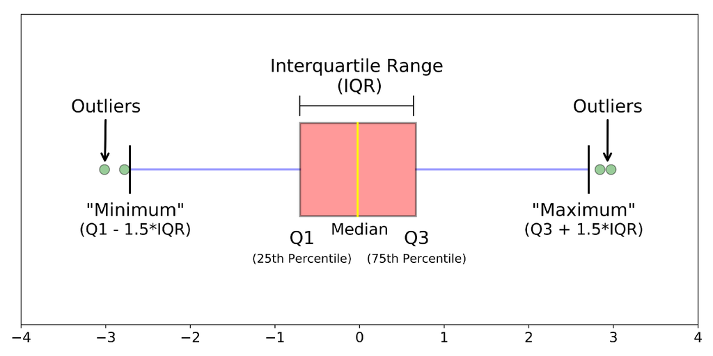

`qplot()` fonksiyonuyla boxplot grafiği çizmek için `geom="boxplot"` argümanı seçilir. Buna göre `melanoma` verisindeki kalınlık değişkenin boxplot grafiği aşağıdaki gibi elde edilir. Burada tek değişkene ihtiyaç olduğundan `y` argümanına herhangi bir değer girilmemektedir.

```r
qplot(data=melanoma,x=thickness,geom="boxplot")
```

[output not shown]

Aynı değişkenin farklı durumlara göre boxplot grafiklerini çizmek için `y` argümanına ilgili faktör değişkeni girilebilir.

```r
qplot(data=melanoma,x=thickness,
      y=status,geom="boxplot")
```

[output not shown]

Burada boxplot grafiklerini dikey yapmak için status değişkenini `x` argümanına (eksenine) ve `thickness` değişkenini de `y` argümanına (eksenine) yerleştirmek yeterlidir.

```r
qplot(data=melanoma,y=thickness,x=status,
      geom="boxplot")
```

[output not shown]

Bu kutuların içerisini status değişkenine göre farklılaşan renklerle doldurabiliriz.

```r
qplot(data=melanoma,y=thickness,x=status,
      geom="boxplot",fill=status)
```

[output not shown]

Şimdi bu grafikleri `ggplot()` fonksiyonuyla elde etmeye çalışalım. Bunun için `geom_boxplot()` fonksiyonu kullanılır.

```r
c<-ggplot(data=melanoma,aes(x=thickness))
c
```

[output not shown]

Şimdi c kanvasına ilgili boxplot grafiklerini ekleyebiliriz.

```r
c+geom_boxplot()
```

[output not shown]

qplot() fonksiyonuyla yapıldığı gibi status değişkenine göre farklı boxplotlar çizilebilir.

```r
ggplot(data=melanoma,aes(x=status, y=thickness))+
  geom_boxplot()
```

[output not shown]

Son olarak burada yine ggsci paketindeki renk seçeneklerinden birisi kullanılabilir.

```r
ggplot(data=melanoma,aes(x=status, y=thickness))+
  geom_boxplot(aes(fill=status))+
  scale_fill_d3()
```

[output not shown]

## 4.2 Keman (Violin) Grafikleri

Bu grafikler de aslında gruplanmış `boxplot()` grafiklerine benzemekte olup, farklı olarak gözlemlerin görülme sıklıklarına göre yoğunluklarını da görselleştirerek kuru yerine kemana benzeyen bir görüntü ortaya çıkarmaktadırlar. Burada ggplot() fonksiyonuyla violin grafiği gösterilecektir.

```r
d<-ggplot(data=melanoma,aes(x=status,y=thickness))
d+geom_violin()
```

[output not shown]

İlgili kemanları hasta durumlarına göre aşağıdaki gibi renklendirebiliriz.

```r
d+geom_violin(aes(fill=status))+
  scale_fill_d3()
```

[output not shown]

# 5 Saçılım Grafiği

İki sayısal değişkenin birlikte değişimlerinin ve aralarındaki ilişki yapısının incelenmesi amacıyla kullanılan grafik türüdür. Genellikle trendi gözlemlemek için kullanılır.

pressure verisindeki sıcaklık ve basınç değişkenkeri için saçılım grafiğini oluşturunuz.

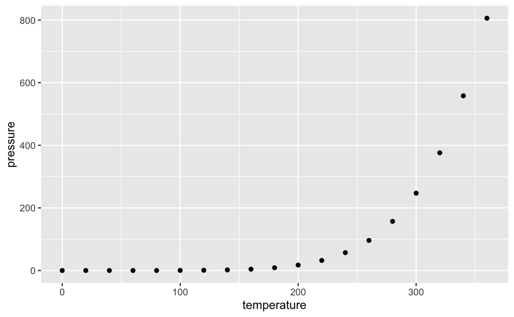

```r
library(ggplot2)
qplot(data=pressure,x=temperature,
      y=pressure,
      geom="point")
```

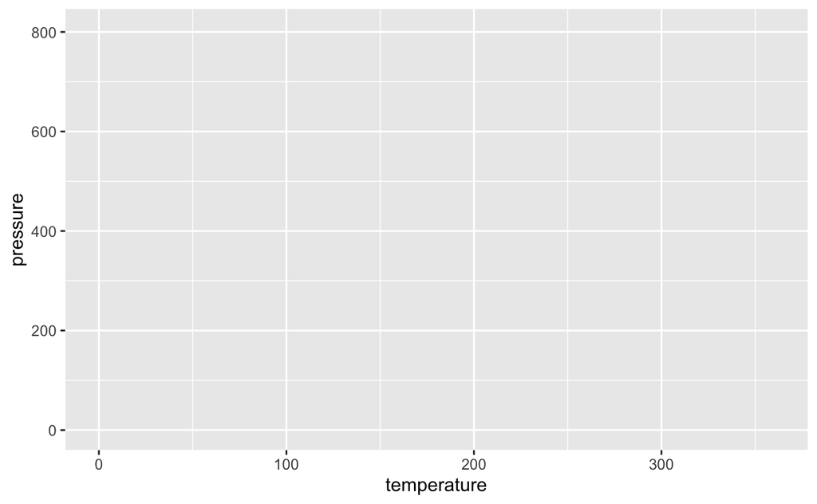

```r
e<-ggplot(data=pressure,
          aes(x=temperature,y=pressure))
e
```

Artık oluşturduğumuz bu kanvas üzerine grafiği farklı şekillerde oluşturabiliriz.

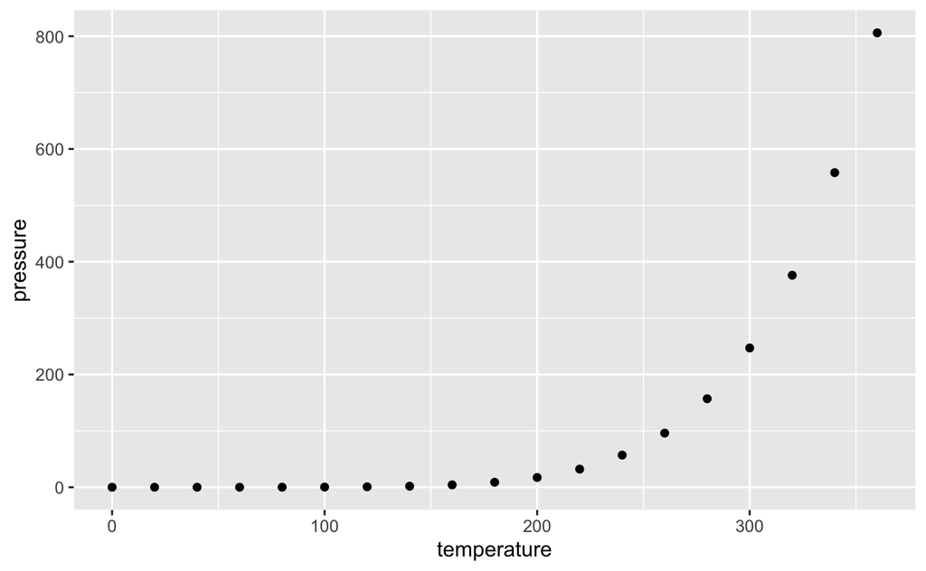

```r
e+geom_point()
```

Burada noktalar üzerinde değişiklikler yapmak için geom_point() fonksiyonu kullanılabilir. Noktaların çevre rengi color, iç rengi fill, şekli size ve biçimi shape argüanlarıyla değiştirilir.

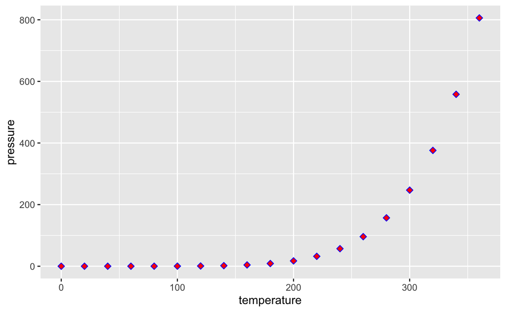

```r
e+geom_point(fill="red",shape=23,
             color="blue",size=2)
```

Şimdi de melanoma verisindeki yaş ve kalınlık değişkenlerinin saçılım grafiğini oluşturalım.

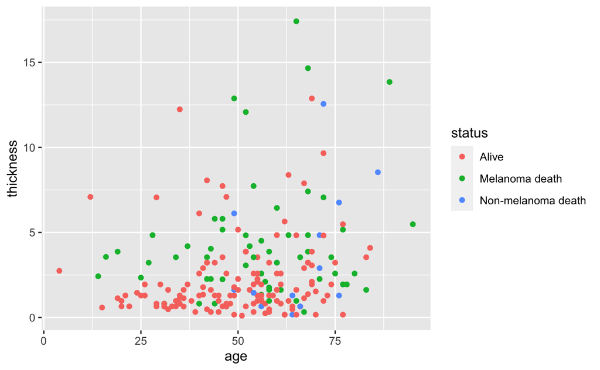

```r
ggplot(data=melanoma,aes(x=age,y=thickness))+
  geom_point(aes(col=status))
```

Burada ilave argüman ve fonksiyonlarla grafiği daha güçlü bir görsele kavuşturabiliriz. Buradaki shape değeri içi boyanabilir olan nokta türlerinden (21-25) olmalıdır.

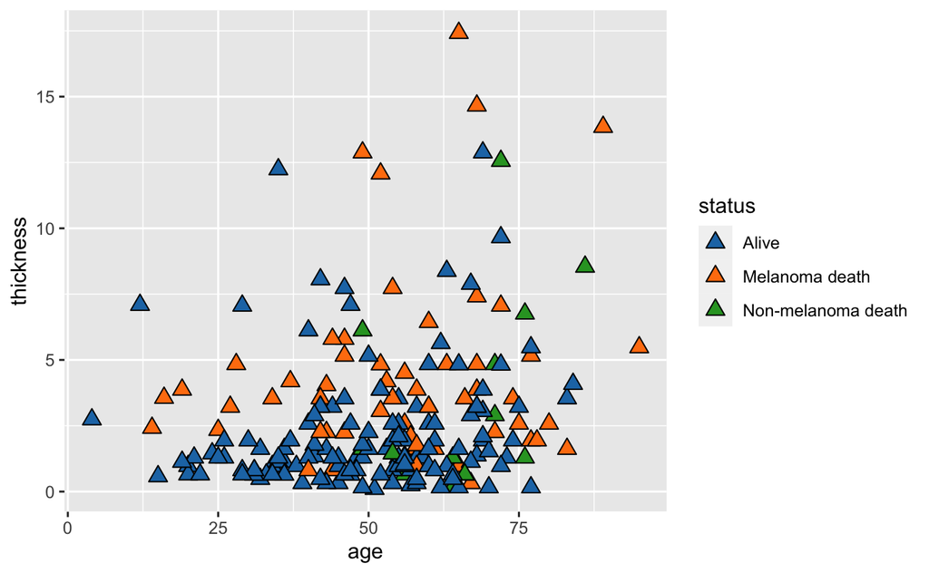

```r
library(ggsci)
ggplot(data=melanoma,aes(x=age,y=thickness))+
  geom_point(aes(fill=status),shape=24,size=3)+
  scale_fill_d3()
```

# 6 Köpük Grafiği (Bubble Plot)

İstersek farklı bir sayısal değişken bakımından noktaların aldıkları değerleri nokta büyüklükleri olarak tanımlayarak, bir köpük grafiği elde edebiliriz. Bir diğer ifadeyle köpük grafiği 3 sayısal değişkenin aynı anda görselleştirilebilmesine imkan vermektedir.

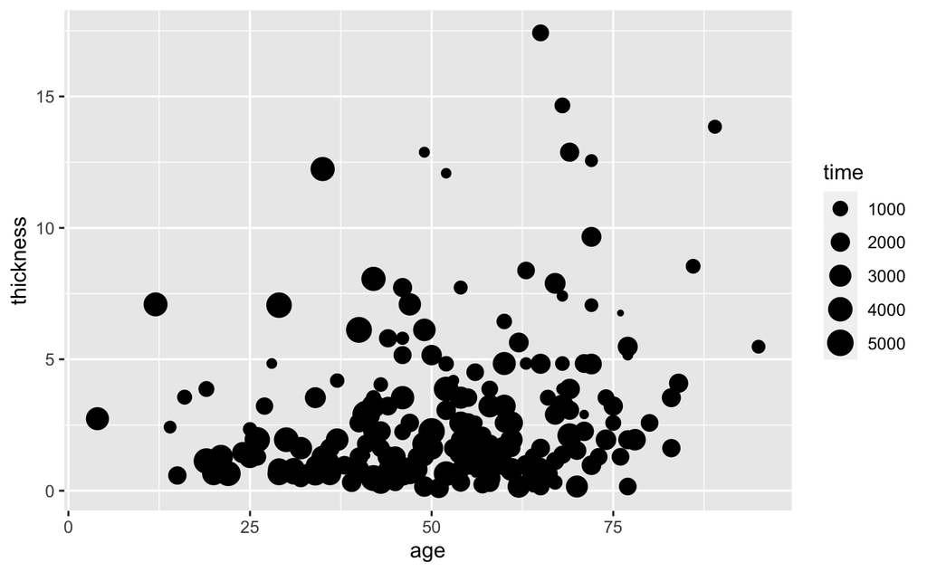

```r
ggplot(data=melanoma,aes(x=age,y=thickness))+
  geom_point(aes(size=time))
```

Hatta aynı anda bu noktaların içini de statüye göre renklendirebiliriz. Böylece dördüncü değişkeni de grafiğe eklemiş olacağız.

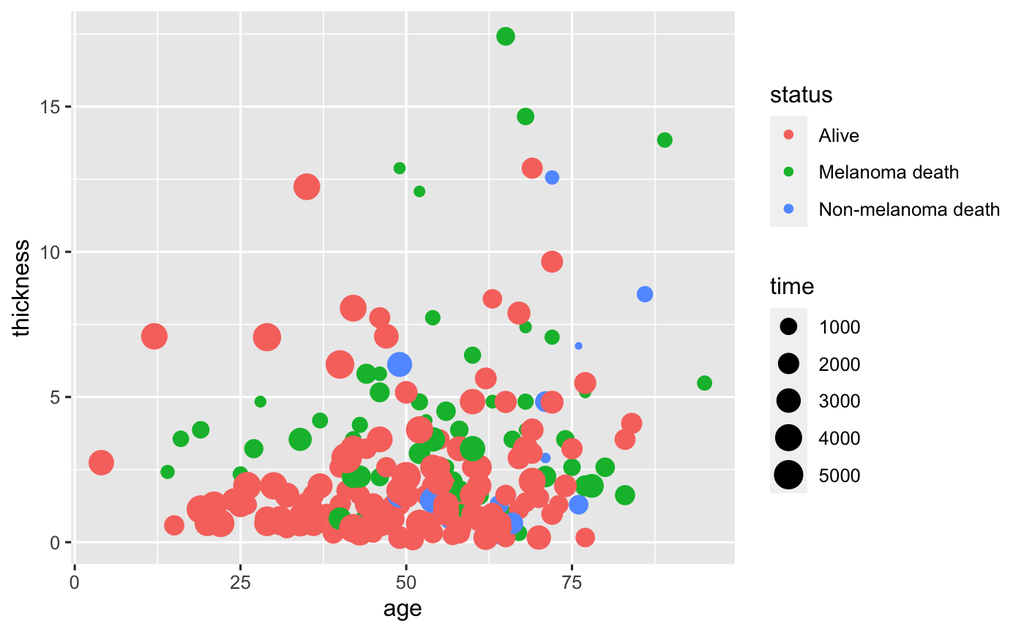

```r
ggplot(data=melanoma,aes(x=age,y=thickness))+
  geom_point(aes(size=time,col=status))
```

Şimdi de iris verisinin ilk 3 değişkeni için bir köpük grafiği oluşturalım. Bu grafikte çiçek türlerini de renklendirme aracı olarak kullanarak dördüncü değişkeni grafiğe eklemiş olalım.

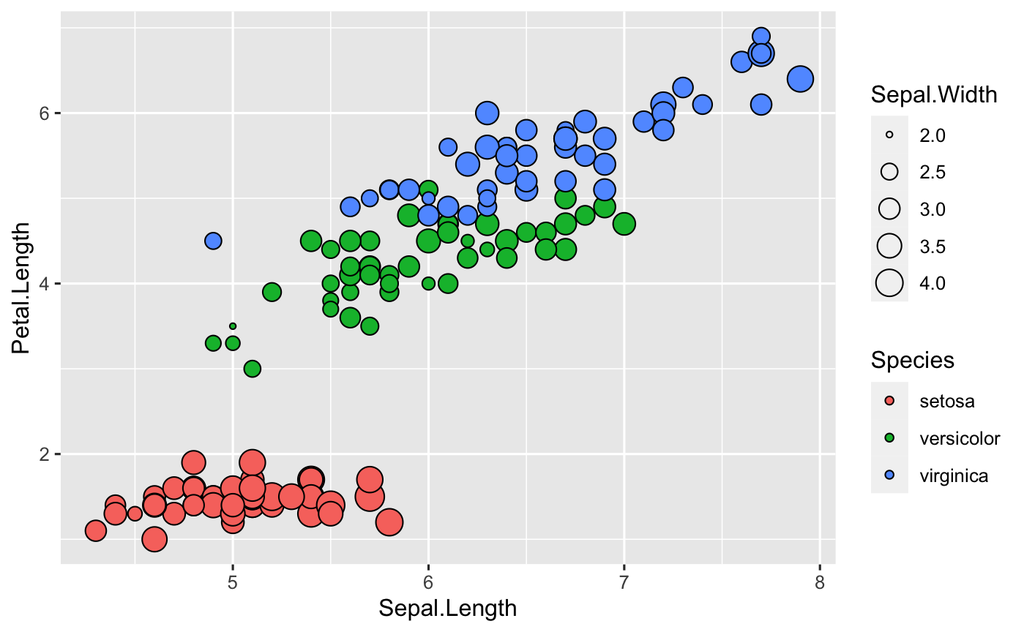

```r
f<-ggplot(data=iris,aes(x=Sepal.Length,y=Petal.Length))+
  geom_point(aes(size=Sepal.Width,fill=Species),shape=21)
f
```

Grafiğe başlık eklemek ve eksenleri düzenlemek için aşağıdaki kodlar kullanılabilir. Burada labs fonksiyonu başlık eklemek için, scale_x_continuous() fonksiyonu x exseninin adını ve sınırlarını, scale_y_continuous() fonksiyonu ise y ekseninin adını ve sınırlarını belirlemek için kullanılır. scale_fill_d3() fonksiyonu otomatik renk seçimi yapar, ayrıca renklerin ifade edildiği etiketin başlığını name argümanıyla, renklerin saydamlığını da alpha argümanıyla belirler. Son olarak scale_size() fonksiyonu noktaların size değerinin belirleyen değişkenle ilgili düzenlemelerin yapılmasına izin verir ve burada sadece ilgili noktaların ismini name argümanıyla değiştirmiştir.

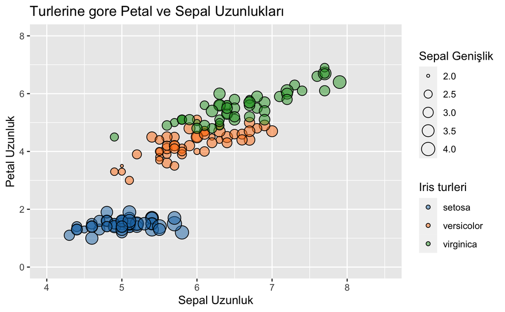

```r
f <- f +
  labs(title = "Turlerine gore Petal ve Sepal Uzunlukları") +
  scale_x_continuous(name = "Sepal Uzunluk", limits = c(4, 8.5)) +
  scale_y_continuous(name = "Petal Uzunluk", limits = c(0, 8))+
  scale_fill_d3(name = "Iris turleri", alpha = 0.5) +
  scale_size(name = "Sepal Genişlik")
f
```

Şimdi `MSMwRA` paketinde bulunan ecodata’yı aşağıdaki gibi aktive edelim.

```r
library(MSMwRA)
data(ecodata)
str(ecodata)
```

```
'data.frame':   81 obs. of  4 variables:
 $ Cities: Factor w/ 81 levels "Adana","Adiyaman",..: 1 2 3 4 5 6 7 8 9 10 ...
 $ X1    : num  43.3 39.2 51.1 53.2 47.2 47.4 44.5 52.9 59.1 47.1 ...
 $ X2    : num  13.2 9.1 5.6 6.8 5.8 6.6 10.2 7.9 5.8 7.1 ...
 $ X3    : num  73.3 64.3 85.3 64 85.7 88.7 78.9 78.6 70.2 84.9 ...
```

Bu verideki x1 ve x2 değişkeninin karşılıklı saçılım grafiğini elde edeceğiz. Noktaların büyüklüğünü x3 değişkenine göre belirleyeceğiz.

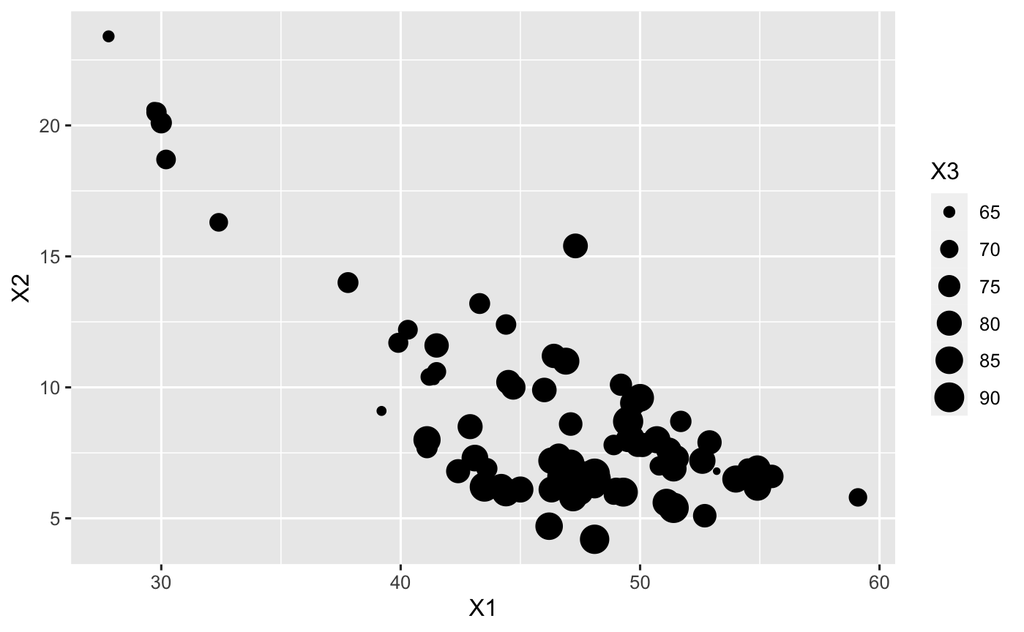

```r
ggplot(ecodata,aes(x=X1,y=X2))+
  geom_point(aes(size=X3))
```

Şimdi bu noktaların hangi illere ait olduğunu `geom_text()` fonksiyonuyla grafiğe ekleyelim.

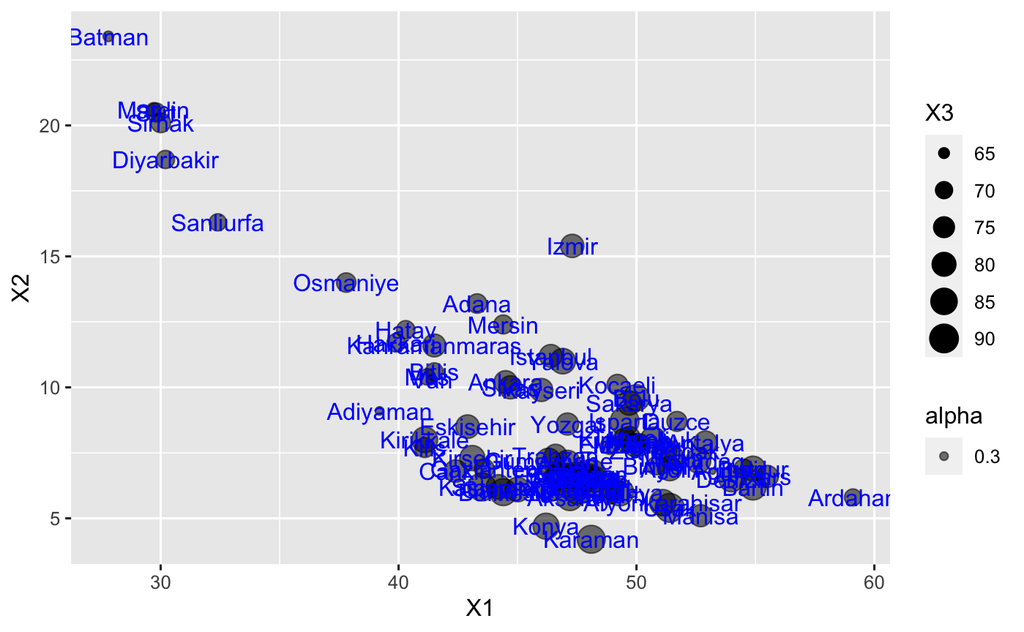

```r
ggplot(ecodata,aes(x=X1,y=X2))+
  geom_point(aes(size=X3,alpha=0.3))+
  geom_text(aes(label=Cities),col="blue")
```

Değerler çok iç içe girdiği için geom_text() fonksiyonu içerisinde `check_overlap = TRUE` argümanı eklenebilir.

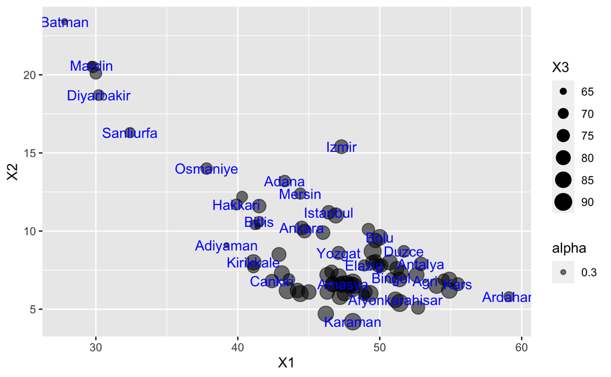

```r
ggplot(ecodata,aes(x=X1,y=X2))+
  geom_point(aes(size=X3,alpha=0.3))+
  geom_text(aes(label=Cities),col="blue",
            check_overlap = TRUE)
```

# 7 Grafiklerin Kombine Edilmesi

ggplot2 paketinin en büyük avantajı farklı grafik türlerini aynı kanvas üzerinde üst üste kullanarak çok farklı grafikler ve görseller elde edilebilmesine olanak sağlamaktadır.

Örneğin hem boxplot hem de violin grafiği aşağıdaki gibi birleştirilebilir.

```r
ggplot(data=melanoma,aes(x=status,y=thickness))+
  geom_boxplot(aes(fill=status))+
  geom_violin(aes(fill=status))
```

[output not shown]

```r
ggplot(data=melanoma,aes(x=status,y=thickness))+
  geom_boxplot(aes(fill=status))+
  geom_violin(aes(fill=status))+
  geom_point()
```

[output not shown]

```r
ggplot(data=melanoma,aes(x=status,y=thickness))+
  geom_boxplot(aes(fill=status))+
  geom_violin(aes(fill=status))+
  geom_jitter()
```

[output not shown]

Burada kalınlık değişkenini hasta durumuna göre görselleştirmiş olduk. Bu grafiğe cinsiyet değişkenini de eklemek istersek facet_grid() fonksiyonundan yararlanılabilir.

```r
ggplot(data=melanoma,aes(x=status,y=thickness))+
  geom_boxplot(aes(fill=status))+
  geom_violin(aes(fill=status))+
  geom_jitter()+
  facet_grid(~sex)
```

[output not shown]

Hatta burada hasta durumuna göre kategorize etmeyi de aşağıdaki şekilde facet_grid() fonksiyonu içerisinde gerçekleştirerek daha ayrıntılı ve sade bir grafik elde edilebilir.

```r
ggplot(data=melanoma,aes(x=status,y=thickness))+
  geom_boxplot(aes(fill=status))+
  geom_violin(aes(fill=status))+
  geom_jitter(size=0.2)+
  facet_grid(status~sex)
```

[output not shown]

```r
ggplot(data=melanoma,aes(x=status,y=thickness))+
  geom_boxplot(aes(fill=sex))+
  geom_violin(aes(fill=sex))+
  geom_jitter(size=0.2)
```

[output not shown]

Bir verinin normal dağılıma benzeyen veya yakın bir yapıda olup-olmadığını belirlemek için kullanılabilecek yapı histogram ve yoğunluk grafiklerini kullanmaktır. Bu grafikler de bir arada aşağıdaki gibi kullanılabilir. Ancak burada histogram grafiğinin y ekseninde frekanslar varken, yoğunluk grafiğinde y ekseninde yoğunluklar raporlanmaktadır. Burada uyumu yakalamak için geom_histogram() fonksiyonunda aes fonksiyonunun y argümanına ..density.. ifadesi girilir. Böylece histogramın y-ekseni de yoğunluklara dönüştürülmüş olacaktır. İlgili fonksiyonlardaki diğer argüman kullanımları öncekiler ile aynıdır.

```r
ggplot(data=melanoma,aes(x=thickness))+
  geom_histogram(aes(y=..density..),bins=30)+
  geom_density()
```

[output not shown]

Burada da status değişkenine göre ayrı ayrı histogram ve yoğunluk grafikleri elde etmek için facet_grid() fonksiyonu aşağıdaki gibi kullanılabilir.

```r
ggplot(data=melanoma,aes(x=thickness))+
  geom_histogram(aes(y=..density..),bins=30)+
  geom_density(aes(fill=status),alpha=0.4)+
  facet_grid(.~status)
```

[output not shown]

# 8 Kullanılabilecek Alternatif Grafik Türleri

## 8.1 Nokta Grafiği

Histogram grafiği yerine kullanılabilecek bu grafikte aslında histogramdan farklı olarak dikdörtgen yerine üst üste bindirilmiş noktalar görselleştirilmektedir. Literatürdeki grafiklerden farklılık elde etmek ve veri görselleştirme yeteneğinizi örneklendirmek istediğinizde kullanılabilir. Bu amaçla kullanılacak fonksiyon ise geom_dotplot() fonksiyonudur. Burada binwidth argümanına verilen değer noktaların büyüklüğünü belirlemekte olup, değer küçüldükçe noktalar da küçülmektedir.

```r
ggplot(data=melanoma,aes(x=thickness))+
  geom_dotplot(aes(fill=status),binwidth=0.4)
```

[output not shown]

## 8.2 QQ Plot Grafiği

Bu grafik verinin normal dağılıma sahip olup-olmadığını görsel olarak incelemek için kullanılır. Burada kullanılacak anahtar fonksiyon `stat_qq()` fonksiyonudur. 45 derecelik açıdan sapmalar verinin normal dağılımdan uzaklaştığını ifade etmektedir. QQ plot grafiği teorik dağılımla örnekten elde edilen deneysel dağılımı karşılaştırdığından, önceki grafiklerden farklı olarak `aes` fonksiyonunda ilgili değişken `sample` argümanına atanmıştır.

```r
ggplot(data=melanoma,aes(sample=thickness))+
  stat_qq()+
  stat_qq_line(col="red")
```

[output not shown]

```r
ks.test(melanoma$thickness,"pnorm")
```

[output not shown]

## 8.3 Manuel şekil, renk ve büyüklük belirleme

iris verisindeki 3 sayısal değişken ve bir kategorik değişken için köpük grafiği aşağıdaki gibi oluşturulabilir.

```r
ggplot(data=iris,aes(x=Sepal.Length,y=Petal.Length))+
  geom_point(aes(size=Sepal.Width,color=Species,shape=Species))
```

[output not shown]

Böylece grafiğe 4 farklı değişken (3 nicel ve 1 kategorik) yansıtılmıştır.

Grafikteki noktaların şekil, renk ve boyutlarını manuel olarak düzenlemek için ise sırasıyla `scale_shape_manual(), scale_color_manual()` ve `scale_size_manual()` fonksiyonları kullanılabilir. Ancak burada manuel olarak girilse de gözlemlerin hangi değişkene göre şekil, boyut ve rengin belirleneceğinin `geom_point()` fonksiyonunda belirtilmesi gerekmektedir. Önceki yapıdan farklı olarak burada sadece verilecek değerleri kullanıcı kesin olarak belirleme fırsatı yakalamaktadır.

```r
ggplot(data=iris,aes(x=Sepal.Length,y=Petal.Length))+
  geom_point(aes(size=Species,color=Species,shape=Species))+
  scale_size_manual(values=c(1,3,5))+
  scale_color_manual(values=c("red","blue","brown"))+
  scale_shape_manual(values=c(3,7,10))
```

[output not shown]